# JSONData

GroupB JSON Partners

June 15, 2019

## About JSON

**JSON(JavaScript Object Notation)** is a lightweight text-based open standard designed for human-readable data interchange. Conventions used by JSON are known to programmers, which include C, C++, Java, Python, Perl, etc. The filename extension is **.json.**

### Uses of JSON

- It is used while writing JavaScript based applications that includes browser extensions and websites.
- JSON format is used for serializing and transmitting structured data over network connection.
- It is primarily used to transmit data between a server and web applications.
- Web services and APIs use JSON format to provide public data.
- It can be used with modern programming languages.

### Benefits of JSON

JSON offers the same kind of benefits that XML does for exchanging data in a heterogeneous environment, such as the following:

- **JSON is self-describing.** The syntax and hierachical structer of the JSON strings can in some cases be interpreted by applications that do not already know what data to expect.
- **JSON is simple text.** This fact makes it suitable and safe for transferring across platforms and operating systems that do not readily share more complex document types. As text, JSON can also be readily displayed and edited in simple editors.
- **JSON is compact.** An avearage JSON string is about two thirds of the size of the same data in XML.
- **JSON is easy.** It is easy to learn, easy to read, and easy to understand.

### Data types and syntax

JSON format supports the following data types:

| **Types** | **Description** |
| --- | --- |
| **Number** | double- precision floating-point format in JavaScript (eg. Integer, Fraction, Expenent) |
| **String** | double-quoted Unicode with backslash escaping (eg. “, , /, b(backspace), f(form feed), n(new line), r(carriage return), t(horizontal tab).. ) |
| **Boolean** | true or false |
| **Array** | an ordered sequence of values |
| **Value** | it can be a string, a number, true or false, null etc |
| **Object** | an unordered collection of key:value pairs |
| **Whitespace** | can be used between any pair of tokens |
| **Null** | empty |

JSON syntax is basically considered as a subset of JavaScript syntax; it includes the following:

- Data is represented in name/value pairs.
- Curly braces hold objects and each name is followed by ‘:’(colon), the name/value pairs are separated by , (comma).
- Square brackets hold arrays and values are separated by ,(comma).

**Simple syntax example in JSON**

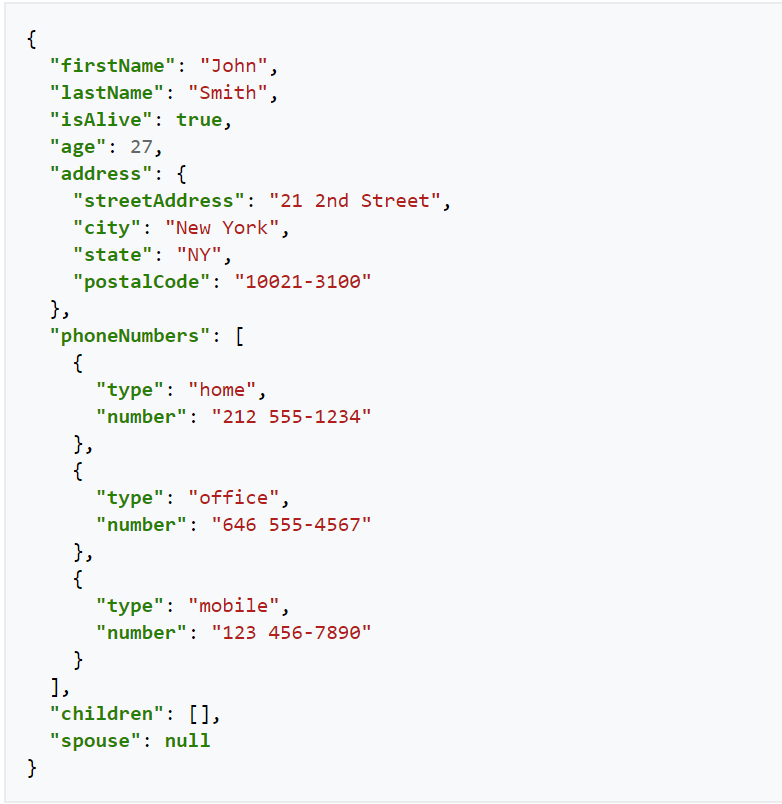

*For more detail about JSON see https://www.tutorialspoint.com/json/json_overview.htm*

## Read and Manipulate JSON

To read JSON data type,we need to install some pacakages such as `jsonlite`. Then, we can read the data easily using the `fromJSON` function. The jsonlite package is a JSON parser/generator optimized for the web. It’s main strength is that it implements a bidirectional mapping between JSON data and the most important R data types. Thereby we can convert between R objects and JSON without loss of type or information.

| **Function Options in jsonlite** | **Description** |
| --- | --- |
| **`read_json`** | to read or write JSON files |
| **`toJSON` or `fromJSON`** | to convert R objects to/from JSON |
| **`unbox`** | unbox a vector or data frame |
| **`flatten`** | Flatten nested data frames |

### JSON Manipulation Practice

For practice lets bring the JSON data sample (which have three categorical variables and two quantitative variables) from [NCHS-Leading Causes of Death:United States](https://catalog.data.gov/dataset/age-adjusted-death-rates-for-the-top-10-leading-causes-of-death-united-states-2013).

*This dataset presents the age-adjusted death rates for the 10 leading causes of death in the United States beginning in 1999. Data are based on information from all resident death certificates filed in the 50 states and the District of Columbia using demographic and medical characteristics. Age-adjusted death rates (per 100,000 population) are based on the 2000 U.S. standard population.*

Since there are no column names in the JSON dataset, add the column names using `colnames()` function.

```r
## install.package("jsonlite")
library(jsonlite)
options(digits=10)

data<-fromJSON("ProjectData.json")
subdata<- data.frame(data$data[,c(9,11,12,13,14)])
colnames(subdata) <- c("Year", "Cause", "State", "Deaths", "DeathRate")
#Change the State and Cause columns from factors to characters.
subdata$State <- as.character(subdata$State)
subdata$Cause <- as.character(subdata$Cause)
#Change the Deaths and DeathRate columns from factors to numerics.
subdata$Deaths <- as.numeric(as.character(subdata$Deaths))
subdata$DeathRate <- as.numeric(as.character(subdata$DeathRate))
str(subdata)
```

```
## 'data.frame':    10296 obs. of  5 variables:
##  $ Year     : Factor w/ 18 levels "1999","2000",..: 14 18 15 2 16 11 13 17 16 15 ...
##  $ Cause    : chr  "Kidney disease" "Kidney disease" "Kidney disease" "Suicide" ...
##  $ State    : chr  "Vermont" "Vermont" "Vermont" "District of Columbia" ...
##  $ Deaths   : num  21 30 30 23 325 29 49 39 37 374 ...
##  $ DeathRate: num  2.6 3.7 3.8 3.8 4.1 4.4 4.5 4.5 4.5 4.9 ...
```

## Analysis

### Top 10 causes of death in North Carolina

#### Numeric Summaries

We can see North Carolina #1 cause of Death was Cancer 19,523 people died(Rate is 162 per 100,000 population) in 2016.

Top 10 Causes of Death in North Carolina in the Year 2016

| Year | Cause | Deaths | DeathRate | CauseProp |
| --- | --- | --- | --- | --- |
| 2016 | Cancer | 19523 | 162 | 0.22 |
| 2016 | Heart disease | 18266 | 156 | 0.20 |
| 2016 | Unintentional injuries | 5476 | 52 | 0.06 |
| 2016 | CLRD | 5311 | 45 | 0.06 |
| 2016 | Stroke | 4940 | 43 | 0.05 |
| 2016 | Alzheimer’s disease | 4153 | 37 | 0.05 |
| 2016 | Diabetes | 2811 | 24 | 0.03 |
| 2016 | Kidney disease | 2002 | 17 | 0.02 |
| 2016 | Influenza and pneumonia | 1896 | 16 | 0.02 |
| 2016 | Suicide | 1373 | 13 | 0.02 |

#### Visual Summaries

From the cause proportion, We can easily see that Cancer account for 22% of all deaths and Heart disease account for 20% in 2016.

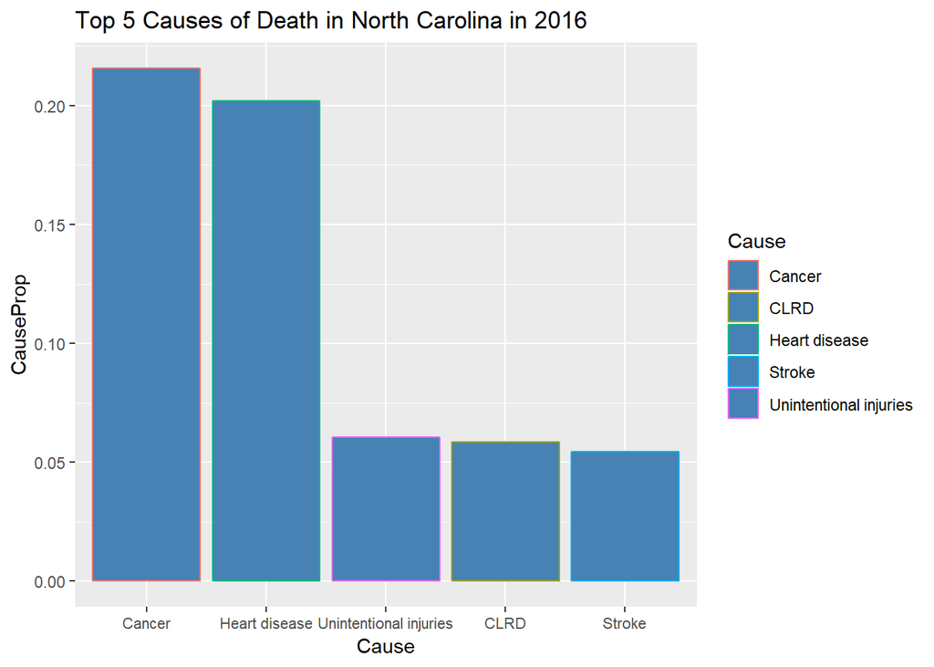

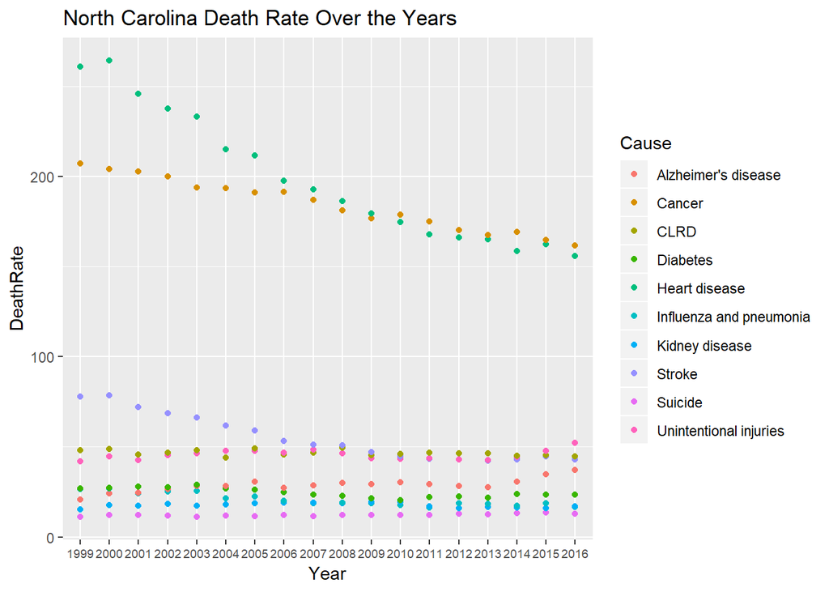

### Causes of death in California, New York, and North Carolina

#### Numeric Summaries

|  | Year | State | Cause | DeathRate |
| --- | --- | --- | --- | --- |
| 1 | 2014 | California | Cancer | 144.1 |
| 2 | 2014 | California | Heart disease | 142.2 |
| 3 | 2014 | New York | Heart disease | 178.3 |
| 4 | 2014 | New York | Cancer | 151.8 |
| 5 | 2014 | North Carolina | Cancer | 169.3 |
| 6 | 2014 | North Carolina | Heart disease | 158.7 |
| 7 | 2015 | California | Heart disease | 145.6 |
| 8 | 2015 | California | Cancer | 142.8 |
| 9 | 2015 | New York | Heart disease | 181.6 |
| 10 | 2015 | New York | Cancer | 148.4 |

[output cut: 8 more lines]

|  | Year | Cause | State | DeathRate |
| --- | --- | --- | --- | --- |
| 1 | 2016 | Influenza and pneumonia | California | 14 |
| 2 | 2014 | Influenza and pneumonia | California | 14.7 |
| 3 | 2015 | Influenza and pneumonia | California | 14.8 |
| 4 | 2012 | Influenza and pneumonia | California | 15.2 |
| 5 | 2011 | Influenza and pneumonia | North Carolina | 16.3 |
| 6 | 2010 | Influenza and pneumonia | California | 16.4 |
| 7 | 1999 | Influenza and pneumonia | California | 16.5 |
| 8 | 2016 | Influenza and pneumonia | North Carolina | 16.5 |
| 9 | 2013 | Influenza and pneumonia | California | 16.6 |
| 10 | 2011 | Influenza and pneumonia | California | 16.6 |

[output cut: 44 more lines]

#### Visual Summaries

California’s 1st and 2nd cause of death were very similar during 2014 to 2016.  
North Carolina’s 1st cause of death was cancer during 2014 to 2016. But Cancer Death Rate have been improved.  
Newyork’s 1st cause of death was Heart disease during 2014 to 2016 and it is higher than other two states.

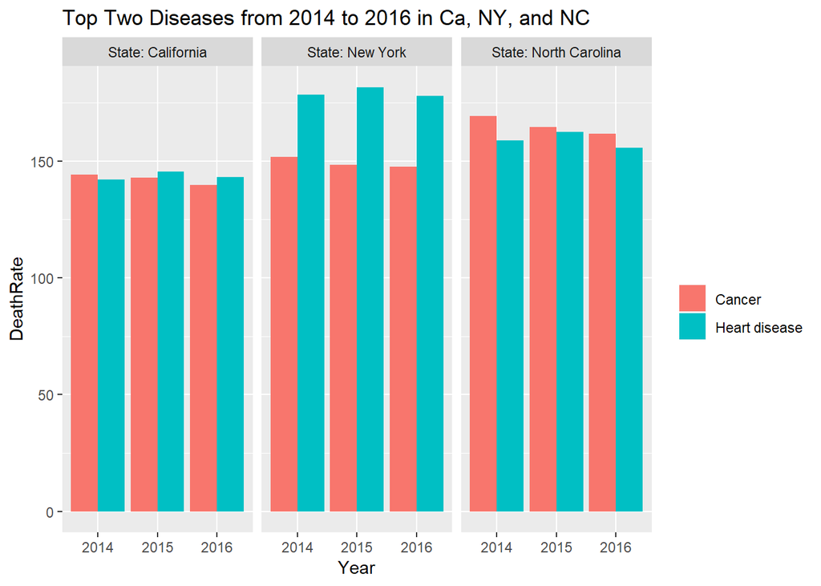

The death rates from the influenza virus were similar in California, New York, and North Carolina. New York has a slightly higher death rate from influenza than North Carolina or California.

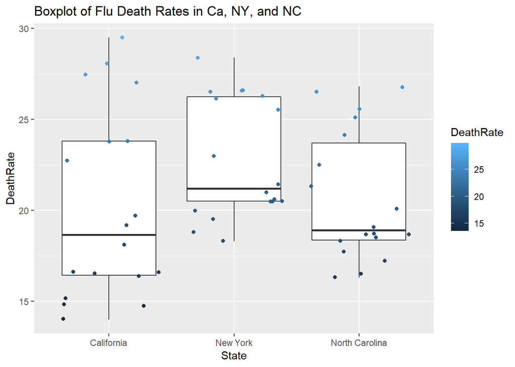